# Risk Factor Analysis

## Outcome Variable

**Outcome Variable:** whz

## Predictor Variables

**Intervention Variable:** rain_quartile

**Adjustment Set:**

unadjusted

## Stratifying Variables

The analysis was stratified on these variable(s):

- studyid
- country

## Data Summary

| studyid | country | rain_quartile | n_cell | n |
| --- | --- | --- | --- | --- |
| CMC-V-BCS-2002 | India | Opposite max rain | 2176 | 8697 |
| CMC-V-BCS-2002 | India | Post-max rain | 2202 | 8697 |
| CMC-V-BCS-2002 | India | Pre-max rain | 2142 | 8697 |
| CMC-V-BCS-2002 | India | Max rain | 2177 | 8697 |
| CMIN | Bangladesh | Opposite max rain | 1284 | 5372 |
| CMIN | Bangladesh | Post-max rain | 1378 | 5372 |
| CMIN | Bangladesh | Pre-max rain | 1336 | 5372 |
| CMIN | Bangladesh | Max rain | 1374 | 5372 |
| CONTENT | Peru | Opposite max rain | 2150 | 8339 |
| CONTENT | Peru | Post-max rain | 2136 | 8339 |
| CONTENT | Peru | Pre-max rain | 2023 | 8339 |
| CONTENT | Peru | Max rain | 2030 | 8339 |
| EE | Pakistan | Opposite max rain | 1987 | 8427 |
| EE | Pakistan | Post-max rain | 2202 | 8427 |
| EE | Pakistan | Pre-max rain | 2106 | 8427 |
| EE | Pakistan | Max rain | 2132 | 8427 |
| GMS-Nepal | Nepal | Opposite max rain | 3315 | 13340 |
| GMS-Nepal | Nepal | Post-max rain | 3414 | 13340 |
| GMS-Nepal | Nepal | Pre-max rain | 3116 | 13340 |
| GMS-Nepal | Nepal | Max rain | 3495 | 13340 |
| Guatemala BSC | Guatemala | Opposite max rain | 616 | 2545 |
| Guatemala BSC | Guatemala | Post-max rain | 651 | 2545 |
| Guatemala BSC | Guatemala | Pre-max rain | 591 | 2545 |
| Guatemala BSC | Guatemala | Max rain | 687 | 2545 |
| IRC | India | Opposite max rain | 2436 | 9729 |
| IRC | India | Post-max rain | 2490 | 9729 |
| IRC | India | Pre-max rain | 2345 | 9729 |
| IRC | India | Max rain | 2458 | 9729 |
| Keneba | Gambia | Opposite max rain | 9260 | 40115 |
| Keneba | Gambia | Post-max rain | 10262 | 40115 |
| Keneba | Gambia | Pre-max rain | 9832 | 40115 |
| Keneba | Gambia | Max rain | 10761 | 40115 |
| MAL-ED | Bangladesh | Opposite max rain | 1405 | 5556 |
| MAL-ED | Bangladesh | Post-max rain | 1407 | 5556 |
| MAL-ED | Bangladesh | Pre-max rain | 1369 | 5556 |
| MAL-ED | Bangladesh | Max rain | 1375 | 5556 |
| MAL-ED | Brazil | Opposite max rain | 1148 | 4665 |
| MAL-ED | Brazil | Post-max rain | 1154 | 4665 |
| MAL-ED | Brazil | Pre-max rain | 1180 | 4665 |
| MAL-ED | Brazil | Max rain | 1183 | 4665 |
| MAL-ED | India | Opposite max rain | 1413 | 5649 |
| MAL-ED | India | Post-max rain | 1420 | 5649 |
| MAL-ED | India | Pre-max rain | 1403 | 5649 |
| MAL-ED | India | Max rain | 1413 | 5649 |
| MAL-ED | Nepal | Opposite max rain | 1413 | 5654 |
| MAL-ED | Nepal | Post-max rain | 1419 | 5654 |
| MAL-ED | Nepal | Pre-max rain | 1415 | 5654 |
| MAL-ED | Nepal | Max rain | 1407 | 5654 |
| MAL-ED | Peru | Opposite max rain | 1458 | 5873 |
| MAL-ED | Peru | Post-max rain | 1478 | 5873 |
| MAL-ED | Peru | Pre-max rain | 1483 | 5873 |
| MAL-ED | Peru | Max rain | 1454 | 5873 |
| MAL-ED | South Africa | Opposite max rain | 1513 | 6043 |
| MAL-ED | South Africa | Post-max rain | 1529 | 6043 |
| MAL-ED | South Africa | Pre-max rain | 1518 | 6043 |
| MAL-ED | South Africa | Max rain | 1483 | 6043 |
| MAL-ED | Tanzania | Opposite max rain | 1360 | 5659 |
| MAL-ED | Tanzania | Post-max rain | 1449 | 5659 |
| MAL-ED | Tanzania | Pre-max rain | 1429 | 5659 |
| MAL-ED | Tanzania | Max rain | 1421 | 5659 |
| ResPak | Pakistan | Opposite max rain | 643 | 3164 |
| ResPak | Pakistan | Post-max rain | 731 | 3164 |
| ResPak | Pakistan | Pre-max rain | 770 | 3164 |
| ResPak | Pakistan | Max rain | 1020 | 3164 |
| TanzaniaChild2 | Tanzania | Opposite max rain | 7508 | 29518 |
| TanzaniaChild2 | Tanzania | Post-max rain | 7244 | 29518 |
| TanzaniaChild2 | Tanzania | Pre-max rain | 7333 | 29518 |
| TanzaniaChild2 | Tanzania | Max rain | 7433 | 29518 |

The following strata were considered:

- studyid: CMC-V-BCS-2002, country: India
- studyid: CMIN, country: Bangladesh
- studyid: CONTENT, country: Peru
- studyid: EE, country: Pakistan
- studyid: GMS-Nepal, country: Nepal
- studyid: Guatemala BSC, country: Guatemala
- studyid: IRC, country: India
- studyid: Keneba, country: Gambia
- studyid: MAL-ED, country: Bangladesh
- studyid: MAL-ED, country: Brazil
- studyid: MAL-ED, country: India
- studyid: MAL-ED, country: Nepal
- studyid: MAL-ED, country: Peru
- studyid: MAL-ED, country: South Africa
- studyid: MAL-ED, country: Tanzania
- studyid: ResPak, country: Pakistan
- studyid: TanzaniaChild2, country: Tanzania

## Methods Detail

We’re interested in the causal parameters $E[Y_a]$ for all values of $a \in \mathcal{A}$. These parameters represent the mean outcome if, possibly contrary to fact, we intervened to set all units to have $A=a$. Under the randomization and positivity assumptions, these are identified by the statistical parameters $\psi_a=E_W[E_{Y|A,W}(Y|A=a,W)]$. In addition, we’re interested in the mean of $Y$, $E[Y]$ under no intervention (the observed mean). We will estimate these parameters by using SuperLearner to fit the relevant likelihood factors – $E_{Y|A,W}(Y|A=a,W)$ and $p(A=a|W)$, and then updating our likelihood fit using a joint TMLE.

For unadjusted analyses ($W=\{\}$), initial likelihoods were estimated using Lrnr_glm to estimate the simple $E(Y|A)$ and Lrnr_mean to estimate $p(A)$. For adjusted analyses, a small library containing Lrnr_glmnet, Lrnr_xgboost, and Lrnr_mean was used.

Having estimated these parameters, we will then use the delta method to estimate relative risks and attributable risks relative to a prespecified baseline level of $A$.

# Results Detail

## Results Plots

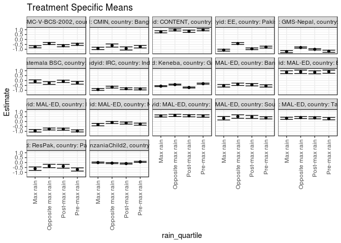

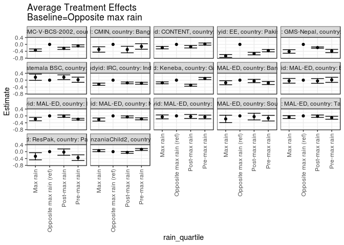

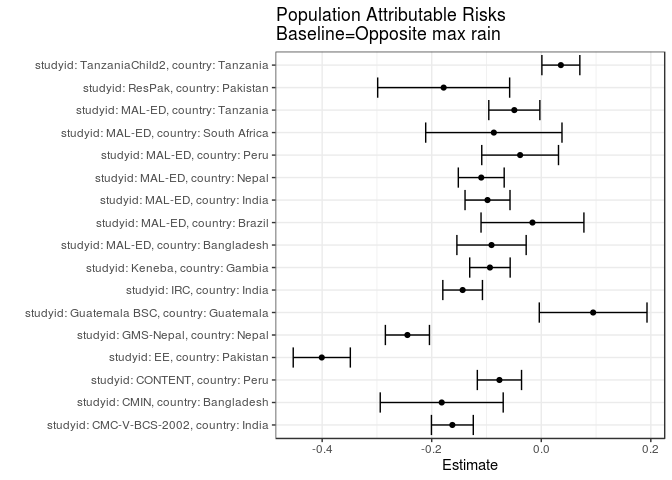

## Results Table

### Parameter: TSM

| studyid | country | intervention_level | baseline_level | estimate | ci_lower | ci_upper |
| --- | --- | --- | --- | --- | --- | --- |
| CMC-V-BCS-2002 | India | Opposite max rain | NA | -0.4067142 | -0.5121081 | -0.3013202 |
| CMC-V-BCS-2002 | India | Post-max rain | NA | -0.6352089 | -0.7440098 | -0.5264080 |
| CMC-V-BCS-2002 | India | Pre-max rain | NA | -0.4912932 | -0.5991165 | -0.3834698 |
| CMC-V-BCS-2002 | India | Max rain | NA | -0.7407763 | -0.8490798 | -0.6324728 |
| CMIN | Bangladesh | Opposite max rain | NA | -0.6135280 | -0.7746471 | -0.4524090 |
| CMIN | Bangladesh | Post-max rain | NA | -0.9119086 | -1.0720185 | -0.7517986 |
| CMIN | Bangladesh | Pre-max rain | NA | -0.7329716 | -0.8600410 | -0.6059022 |
| CMIN | Bangladesh | Max rain | NA | -0.9086754 | -1.0275062 | -0.7898446 |
| CONTENT | Peru | Opposite max rain | NA | 0.9731163 | 0.8665883 | 1.0796443 |
| CONTENT | Peru | Post-max rain | NA | 0.8370646 | 0.7233972 | 0.9507320 |
| CONTENT | Peru | Pre-max rain | NA | 0.9918339 | 0.8852918 | 1.0983760 |
| CONTENT | Peru | Max rain | NA | 0.7838818 | 0.6746891 | 0.8930744 |
| EE | Pakistan | Opposite max rain | NA | -0.4121641 | -0.5032110 | -0.3211172 |
| EE | Pakistan | Post-max rain | NA | -0.9463397 | -1.0338515 | -0.8588279 |
| EE | Pakistan | Pre-max rain | NA | -0.7753324 | -0.8717669 | -0.6788978 |
| EE | Pakistan | Max rain | NA | -1.0855629 | -1.1784370 | -0.9926888 |
| GMS-Nepal | Nepal | Opposite max rain | NA | -0.8186787 | -0.8842050 | -0.7531525 |
| GMS-Nepal | Nepal | Post-max rain | NA | -1.0027973 | -1.0679634 | -0.9376312 |
| GMS-Nepal | Nepal | Pre-max rain | NA | -1.2017651 | -1.3095576 | -1.0939726 |
| GMS-Nepal | Nepal | Max rain | NA | -1.2300029 | -1.3390084 | -1.1209973 |
| Guatemala BSC | Guatemala | Opposite max rain | NA | -0.2560877 | -0.3929840 | -0.1191913 |
| Guatemala BSC | Guatemala | Post-max rain | NA | -0.0868049 | -0.2067583 | 0.0331485 |
| Guatemala BSC | Guatemala | Pre-max rain | NA | -0.2320474 | -0.3741081 | -0.0899867 |
| Guatemala BSC | Guatemala | Max rain | NA | -0.0863173 | -0.2420993 | 0.0694647 |
| IRC | India | Opposite max rain | NA | -0.6754639 | -0.7697086 | -0.5812191 |
| IRC | India | Post-max rain | NA | -0.8327309 | -0.9243528 | -0.7411091 |
| IRC | India | Pre-max rain | NA | -0.8554925 | -0.9531436 | -0.7578415 |
| IRC | India | Max rain | NA | -0.9125753 | -1.0055027 | -0.8196478 |
| Keneba | Gambia | Opposite max rain | NA | -0.4178056 | -0.4664429 | -0.3691683 |
| Keneba | Gambia | Post-max rain | NA | -0.7118408 | -0.7623662 | -0.6613153 |
| Keneba | Gambia | Pre-max rain | NA | -0.3219904 | -0.3790766 | -0.2649043 |
| Keneba | Gambia | Max rain | NA | -0.5742524 | -0.6197415 | -0.5287633 |
| MAL-ED | Bangladesh | Opposite max rain | NA | -0.3829893 | -0.5007748 | -0.2652039 |
| MAL-ED | Bangladesh | Post-max rain | NA | -0.4318905 | -0.5457683 | -0.3180128 |
| MAL-ED | Bangladesh | Pre-max rain | NA | -0.5492330 | -0.6649293 | -0.4335367 |
| MAL-ED | Bangladesh | Max rain | NA | -0.5343273 | -0.6632061 | -0.4054485 |
| MAL-ED | Brazil | Opposite max rain | NA | 0.8816376 | 0.7041005 | 1.0591748 |
| MAL-ED | Brazil | Post-max rain | NA | 0.8361092 | 0.6839291 | 0.9882893 |
| MAL-ED | Brazil | Pre-max rain | NA | 0.9000424 | 0.7403109 | 1.0597738 |
| MAL-ED | Brazil | Max rain | NA | 0.8444379 | 0.6992120 | 0.9896638 |
| MAL-ED | India | Opposite max rain | NA | -0.7595117 | -0.8609678 | -0.6580556 |
| MAL-ED | India | Post-max rain | NA | -0.7762535 | -0.8836289 | -0.6688781 |
| MAL-ED | India | Pre-max rain | NA | -0.9523592 | -1.0589818 | -0.8457367 |
| MAL-ED | India | Max rain | NA | -0.9434536 | -1.0697852 | -0.8171221 |
| MAL-ED | Nepal | Opposite max rain | NA | -0.0974239 | -0.2046466 | 0.0097988 |
| MAL-ED | Nepal | Post-max rain | NA | -0.1530233 | -0.2612951 | -0.0447514 |
| MAL-ED | Nepal | Pre-max rain | NA | -0.2668975 | -0.3750860 | -0.1587090 |
| MAL-ED | Nepal | Max rain | NA | -0.3112011 | -0.4334302 | -0.1889721 |
| MAL-ED | Peru | Opposite max rain | NA | 0.6235048 | 0.5036330 | 0.7433766 |
| MAL-ED | Peru | Post-max rain | NA | 0.5881664 | 0.4787193 | 0.6976136 |
| MAL-ED | Peru | Pre-max rain | NA | 0.5624882 | 0.4402693 | 0.6847071 |
| MAL-ED | Peru | Max rain | NA | 0.5657565 | 0.4568005 | 0.6747126 |
| MAL-ED | South Africa | Opposite max rain | NA | 0.5093457 | 0.3332069 | 0.6854845 |
| MAL-ED | South Africa | Post-max rain | NA | 0.4691040 | 0.3146558 | 0.6235522 |
| MAL-ED | South Africa | Pre-max rain | NA | 0.3767194 | 0.2658902 | 0.4875485 |
| MAL-ED | South Africa | Max rain | NA | 0.3337829 | 0.1589812 | 0.5085846 |
| MAL-ED | Tanzania | Opposite max rain | NA | 0.4012059 | 0.2999134 | 0.5024983 |
| MAL-ED | Tanzania | Post-max rain | NA | 0.3828364 | 0.2783512 | 0.4873217 |
| MAL-ED | Tanzania | Pre-max rain | NA | 0.2937019 | 0.1759963 | 0.4114075 |
| MAL-ED | Tanzania | Max rain | NA | 0.3321605 | 0.2246359 | 0.4396850 |
| ResPak | Pakistan | Opposite max rain | NA | -0.3511198 | -0.5266625 | -0.1755770 |
| ResPak | Pakistan | Post-max rain | NA | -0.3769631 | -0.5723869 | -0.1815393 |
| ResPak | Pakistan | Pre-max rain | NA | -0.7012468 | -0.8634914 | -0.5390021 |
| ResPak | Pakistan | Max rain | NA | -0.6210196 | -0.7993666 | -0.4426726 |
| TanzaniaChild2 | Tanzania | Opposite max rain | NA | -0.0565863 | -0.1094778 | -0.0036948 |
| TanzaniaChild2 | Tanzania | Post-max rain | NA | -0.1003299 | -0.1538980 | -0.0467618 |
| TanzaniaChild2 | Tanzania | Pre-max rain | NA | 0.0741920 | 0.0211281 | 0.1272559 |
| TanzaniaChild2 | Tanzania | Max rain | NA | -0.0009068 | -0.0564422 | 0.0546286 |

### Parameter: E(Y)

| studyid | country | intervention_level | baseline_level | estimate | ci_lower | ci_upper |
| --- | --- | --- | --- | --- | --- | --- |
| CMC-V-BCS-2002 | India | NA | NA | -0.5690192 | -0.6692214 | -0.4688170 |
| CMIN | Bangladesh | NA | NA | -0.7952625 | -0.9007497 | -0.6897752 |
| CONTENT | Peru | NA | NA | 0.8967418 | 0.7963679 | 0.9971157 |
| EE | Pakistan | NA | NA | -0.8128729 | -0.8951633 | -0.7305825 |
| GMS-Nepal | Nepal | NA | NA | -1.0630457 | -1.1281751 | -0.9979164 |
| Guatemala BSC | Guatemala | NA | NA | -0.1613752 | -0.2624299 | -0.0603206 |
| IRC | India | NA | NA | -0.8190122 | -0.9060940 | -0.7319304 |
| Keneba | Gambia | NA | NA | -0.5115077 | -0.5457987 | -0.4772167 |
| MAL-ED | Bangladesh | NA | NA | -0.4737887 | -0.5760725 | -0.3715049 |
| MAL-ED | Brazil | NA | NA | 0.8655970 | 0.7277343 | 1.0034597 |
| MAL-ED | India | NA | NA | -0.8576261 | -0.9556217 | -0.7596305 |
| MAL-ED | Nepal | NA | NA | -0.2069897 | -0.3099921 | -0.1039874 |
| MAL-ED | Peru | NA | NA | 0.5849072 | 0.4912058 | 0.6786086 |
| MAL-ED | South Africa | NA | NA | 0.4227635 | 0.3123898 | 0.5331373 |
| MAL-ED | Tanzania | NA | NA | 0.3520180 | 0.2575723 | 0.4464637 |
| ResPak | Pakistan | NA | NA | -0.5293078 | -0.6629147 | -0.3957010 |
| TanzaniaChild2 | Tanzania | NA | NA | -0.0208120 | -0.0614288 | 0.0198047 |

### Parameter: ATE

| studyid | country | intervention_level | baseline_level | estimate | ci_lower | ci_upper |
| --- | --- | --- | --- | --- | --- | --- |
| CMC-V-BCS-2002 | India | Opposite max rain | Opposite max rain | 0.0000000 | 0.0000000 | 0.0000000 |
| CMC-V-BCS-2002 | India | Post-max rain | Opposite max rain | -0.2284947 | -0.2920971 | -0.1648924 |
| CMC-V-BCS-2002 | India | Pre-max rain | Opposite max rain | -0.0845790 | -0.1416229 | -0.0275351 |
| CMC-V-BCS-2002 | India | Max rain | Opposite max rain | -0.3340621 | -0.4023251 | -0.2657992 |
| CMIN | Bangladesh | Opposite max rain | Opposite max rain | 0.0000000 | 0.0000000 | 0.0000000 |
| CMIN | Bangladesh | Post-max rain | Opposite max rain | -0.2983805 | -0.4884731 | -0.1082879 |
| CMIN | Bangladesh | Pre-max rain | Opposite max rain | -0.1194435 | -0.2815198 | 0.0426328 |
| CMIN | Bangladesh | Max rain | Opposite max rain | -0.2951474 | -0.4542986 | -0.1359962 |
| CONTENT | Peru | Opposite max rain | Opposite max rain | 0.0000000 | 0.0000000 | 0.0000000 |
| CONTENT | Peru | Post-max rain | Opposite max rain | -0.1360517 | -0.2069381 | -0.0651652 |
| CONTENT | Peru | Pre-max rain | Opposite max rain | 0.0187176 | -0.0449597 | 0.0823949 |
| CONTENT | Peru | Max rain | Opposite max rain | -0.1892345 | -0.2587761 | -0.1196929 |
| EE | Pakistan | Opposite max rain | Opposite max rain | 0.0000000 | 0.0000000 | 0.0000000 |
| EE | Pakistan | Post-max rain | Opposite max rain | -0.5341756 | -0.6077901 | -0.4605612 |
| EE | Pakistan | Pre-max rain | Opposite max rain | -0.3631683 | -0.4326764 | -0.2936602 |
| EE | Pakistan | Max rain | Opposite max rain | -0.6733988 | -0.7569713 | -0.5898262 |
| GMS-Nepal | Nepal | Opposite max rain | Opposite max rain | 0.0000000 | 0.0000000 | 0.0000000 |
| GMS-Nepal | Nepal | Post-max rain | Opposite max rain | -0.1841186 | -0.2219417 | -0.1462955 |
| GMS-Nepal | Nepal | Pre-max rain | Opposite max rain | -0.3830864 | -0.4793404 | -0.2868323 |
| GMS-Nepal | Nepal | Max rain | Opposite max rain | -0.4113241 | -0.5150893 | -0.3075589 |
| Guatemala BSC | Guatemala | Opposite max rain | Opposite max rain | 0.0000000 | 0.0000000 | 0.0000000 |
| Guatemala BSC | Guatemala | Post-max rain | Opposite max rain | 0.1692827 | 0.0306408 | 0.3079247 |
| Guatemala BSC | Guatemala | Pre-max rain | Opposite max rain | 0.0240403 | -0.1259370 | 0.1740176 |
| Guatemala BSC | Guatemala | Max rain | Opposite max rain | 0.1697703 | -0.0111709 | 0.3507116 |
| IRC | India | Opposite max rain | Opposite max rain | 0.0000000 | 0.0000000 | 0.0000000 |
| IRC | India | Post-max rain | Opposite max rain | -0.1572670 | -0.2094358 | -0.1050983 |
| IRC | India | Pre-max rain | Opposite max rain | -0.1800287 | -0.2377227 | -0.1223346 |
| IRC | India | Max rain | Opposite max rain | -0.2371114 | -0.3028829 | -0.1713399 |
| Keneba | Gambia | Opposite max rain | Opposite max rain | 0.0000000 | 0.0000000 | 0.0000000 |
| Keneba | Gambia | Post-max rain | Opposite max rain | -0.2940352 | -0.3521170 | -0.2359533 |
| Keneba | Gambia | Pre-max rain | Opposite max rain | 0.0958152 | 0.0311831 | 0.1604473 |
| Keneba | Gambia | Max rain | Opposite max rain | -0.1564468 | -0.2128301 | -0.1000634 |
| MAL-ED | Bangladesh | Opposite max rain | Opposite max rain | 0.0000000 | 0.0000000 | 0.0000000 |
| MAL-ED | Bangladesh | Post-max rain | Opposite max rain | -0.0489012 | -0.1451054 | 0.0473029 |
| MAL-ED | Bangladesh | Pre-max rain | Opposite max rain | -0.1662437 | -0.2559327 | -0.0765547 |
| MAL-ED | Bangladesh | Max rain | Opposite max rain | -0.1513379 | -0.2680507 | -0.0346252 |
| MAL-ED | Brazil | Opposite max rain | Opposite max rain | 0.0000000 | 0.0000000 | 0.0000000 |
| MAL-ED | Brazil | Post-max rain | Opposite max rain | -0.0455284 | -0.1840425 | 0.0929856 |
| MAL-ED | Brazil | Pre-max rain | Opposite max rain | 0.0184047 | -0.1297449 | 0.1665544 |
| MAL-ED | Brazil | Max rain | Opposite max rain | -0.0371998 | -0.1751694 | 0.1007699 |
| MAL-ED | India | Opposite max rain | Opposite max rain | 0.0000000 | 0.0000000 | 0.0000000 |
| MAL-ED | India | Post-max rain | Opposite max rain | -0.0167418 | -0.0867226 | 0.0532389 |
| MAL-ED | India | Pre-max rain | Opposite max rain | -0.1928476 | -0.2460267 | -0.1396684 |
| MAL-ED | India | Max rain | Opposite max rain | -0.1839420 | -0.2834690 | -0.0844150 |
| MAL-ED | Nepal | Opposite max rain | Opposite max rain | 0.0000000 | 0.0000000 | 0.0000000 |
| MAL-ED | Nepal | Post-max rain | Opposite max rain | -0.0555993 | -0.1106043 | -0.0005944 |
| MAL-ED | Nepal | Pre-max rain | Opposite max rain | -0.1694736 | -0.2274706 | -0.1114766 |
| MAL-ED | Nepal | Max rain | Opposite max rain | -0.2137772 | -0.3045919 | -0.1229625 |
| MAL-ED | Peru | Opposite max rain | Opposite max rain | 0.0000000 | 0.0000000 | 0.0000000 |
| MAL-ED | Peru | Post-max rain | Opposite max rain | -0.0353384 | -0.1503292 | 0.0796525 |
| MAL-ED | Peru | Pre-max rain | Opposite max rain | -0.0610166 | -0.1683658 | 0.0463326 |
| MAL-ED | Peru | Max rain | Opposite max rain | -0.0577483 | -0.1715663 | 0.0560698 |
| MAL-ED | South Africa | Opposite max rain | Opposite max rain | 0.0000000 | 0.0000000 | 0.0000000 |
| MAL-ED | South Africa | Post-max rain | Opposite max rain | -0.0402417 | -0.2333635 | 0.1528801 |
| MAL-ED | South Africa | Pre-max rain | Opposite max rain | -0.1326263 | -0.2955772 | 0.0303246 |
| MAL-ED | South Africa | Max rain | Opposite max rain | -0.1755628 | -0.3914100 | 0.0402844 |
| MAL-ED | Tanzania | Opposite max rain | Opposite max rain | 0.0000000 | 0.0000000 | 0.0000000 |
| MAL-ED | Tanzania | Post-max rain | Opposite max rain | -0.0183694 | -0.0878114 | 0.0510725 |
| MAL-ED | Tanzania | Pre-max rain | Opposite max rain | -0.1075040 | -0.1938375 | -0.0211704 |
| MAL-ED | Tanzania | Max rain | Opposite max rain | -0.0690454 | -0.1538470 | 0.0157561 |
| ResPak | Pakistan | Opposite max rain | Opposite max rain | 0.0000000 | 0.0000000 | 0.0000000 |
| ResPak | Pakistan | Post-max rain | Opposite max rain | -0.0258433 | -0.2089488 | 0.1572622 |
| ResPak | Pakistan | Pre-max rain | Opposite max rain | -0.3501270 | -0.5147566 | -0.1854974 |
| ResPak | Pakistan | Max rain | Opposite max rain | -0.2698999 | -0.4777616 | -0.0620381 |
| TanzaniaChild2 | Tanzania | Opposite max rain | Opposite max rain | 0.0000000 | 0.0000000 | 0.0000000 |
| TanzaniaChild2 | Tanzania | Post-max rain | Opposite max rain | -0.0437436 | -0.0985759 | 0.0110887 |
| TanzaniaChild2 | Tanzania | Pre-max rain | Opposite max rain | 0.1307783 | 0.0757007 | 0.1858559 |
| TanzaniaChild2 | Tanzania | Max rain | Opposite max rain | 0.0556795 | -0.0057302 | 0.1170893 |

### Parameter: PAR

| studyid | country | intervention_level | baseline_level | estimate | ci_lower | ci_upper |
| --- | --- | --- | --- | --- | --- | --- |
| CMC-V-BCS-2002 | India | Opposite max rain | NA | -0.1623050 | -0.2005012 | -0.1241088 |
| CMIN | Bangladesh | Opposite max rain | NA | -0.1817344 | -0.2939837 | -0.0694852 |
| CONTENT | Peru | Opposite max rain | NA | -0.0763745 | -0.1167278 | -0.0360211 |
| EE | Pakistan | Opposite max rain | NA | -0.4007088 | -0.4528331 | -0.3485846 |
| GMS-Nepal | Nepal | Opposite max rain | NA | -0.2443670 | -0.2846031 | -0.2041309 |
| Guatemala BSC | Guatemala | Opposite max rain | NA | 0.0947124 | -0.0036150 | 0.1930399 |
| IRC | India | Opposite max rain | NA | -0.1435484 | -0.1797307 | -0.1073660 |
| Keneba | Gambia | Opposite max rain | NA | -0.0937020 | -0.1306165 | -0.0567876 |
| MAL-ED | Bangladesh | Opposite max rain | NA | -0.0907994 | -0.1540407 | -0.0275581 |
| MAL-ED | Brazil | Opposite max rain | NA | -0.0160406 | -0.1099415 | 0.0778603 |
| MAL-ED | India | Opposite max rain | NA | -0.0981145 | -0.1391635 | -0.0570654 |
| MAL-ED | Nepal | Opposite max rain | NA | -0.1095658 | -0.1514315 | -0.0677001 |
| MAL-ED | Peru | Opposite max rain | NA | -0.0385976 | -0.1086523 | 0.0314571 |
| MAL-ED | South Africa | Opposite max rain | NA | -0.0865821 | -0.2109885 | 0.0378242 |
| MAL-ED | Tanzania | Opposite max rain | NA | -0.0491879 | -0.0957906 | -0.0025851 |
| ResPak | Pakistan | Opposite max rain | NA | -0.1781881 | -0.2986388 | -0.0577374 |
| TanzaniaChild2 | Tanzania | Opposite max rain | NA | 0.0357743 | 0.0011238 | 0.0704247 |